# PSPG Bootcamp 2020: PK concepts

Vincent Chang and Jackie Ernest

2020-09-09

**Objectives**

**1) Questions and review from yesterday**  
**2) Familiarize with PK parameters in Rshiny app**  
-Effects of regimen and route of administration  
-Effects of PK parameters: CL, V, Ka, and F  
-Effects of population variability  
**3) Concepts in modeling and simulation in Rshiny app**  
-“Fit” our data from yesterday using Rshiny app  
-Simulate different scenarios by changing dose and frequency

**4) Use PKPDsim to create your own model and simulations**  
-EXCERISE 1: rebuild your model  
-EXERCISE 2: simulate alternate scenarios  
-EXERCISE 3: challenge!  
**PKPDsim documentation:**  
http://pkpdsim.ronkeizer.com/getting-started.html

# Installing and Loading packages

```r
#Comment out if you've already installed them
#install.packages("dplyr")
#install.packages("tidyr")
#install.packages("ggplot2")

#Load libraries
library(dplyr)
library(tidyr)
library(ggplot2)
library(PKPDsim)
```

# EXERCISE 1: Rebuild your Rshiny model using PKPDsim

## Model components

Running a simulation requires THREE arguments:  
1. Model  
2. Parameters  
3. Regimen

## 1. Model

```r
# The PKPDsim library has pre-packaged models.
# They can be viewed by running new_ode_model() with an empty bracket.
# You can deploy them by saving to a variable:

# i.e. my_model <- new_ode_model("pk_1cmt_oral")

# Here we will hard code the model for a 1cmt oral model.
# In your courses, you will learn to write out your own ordinary differential equations (ODE).

my_model <- new_ode_model(code = "
      dAdt[1] = -KA*A[1]
      dAdt[2] = KA*A[1] - CL/V*A[2]
      CP = A[2]/V
      ",
      obs = list(cmt = 2, scale = "V"),
      declare_variables = c("CP"))

# run "my_model" to see the model summary and required parameters

my_model
```

```
## ODE definition:
##
##       dAdt[1] = -KA*A[1];
##       dAdt[2] = KA*A[1] - CL/V*A[2];
##       CP = A[2]/V;
##       ;
##
## Required parameters: KA, CL, V
## Covariates:
## Variables: CP
## Number of compartments: 2
## Observation variable:
## Observation scaling: V
## Lag time:
## IOV CV: {}
## IOV bins: 1
```

## 2. Parameters

```r
# Input your PK parameters you derived from the Rshiny app here:

V = 220 # Central volume (L)
CL = 86 # Clearance (L/h)
KA = 1 # Rate of absorption (1/h)


# We'll store these in a list that PKPDsim can read
my_parameters <- list("V"  = V,
                      "CL" = CL,
                      "KA" = KA
                      )
```

## 3. Regimen

```r
# One single dose of 300 mg at time 0
# Look up ?new_regimen to see arguments this function takes

my_regimen <- new_regimen(amt=300, time=0)
```

## Simulate!

Put it all together  
Use sim() to create a dataset of simulation

```r
# fill in the three arguments with our three components from above
my_simulated_df <- sim(ode = my_model,
                       regimen = my_regimen,
                       parameters = my_parameters,
                       only_obs = T,
                       output_include = list(variables=T)
                       )
# Open your new dataset and understand the set up.
# What is each column? What are the units of each column?
```

## Plot

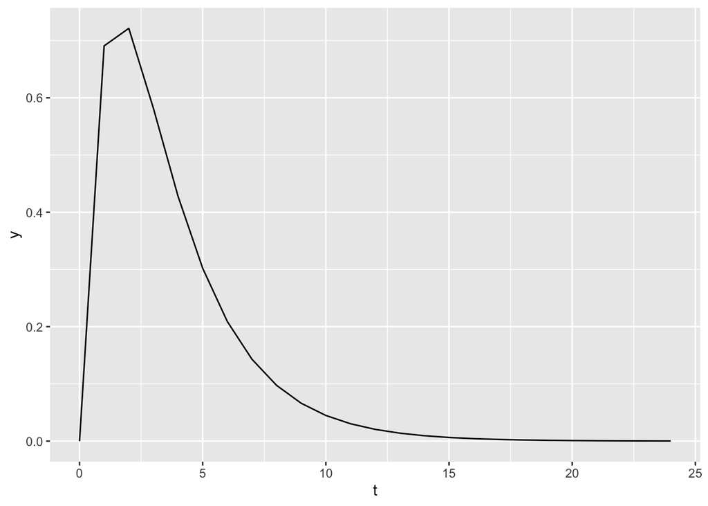

```r
# use ggplot to plot the data (feel free to copy and paste from yesterday's workshop)

ggplot(my_simulated_df, mapping=aes(x=t,y=y))+
  geom_line()
```

```r
# does your plot look similar to your model in the Rshiny app?
```

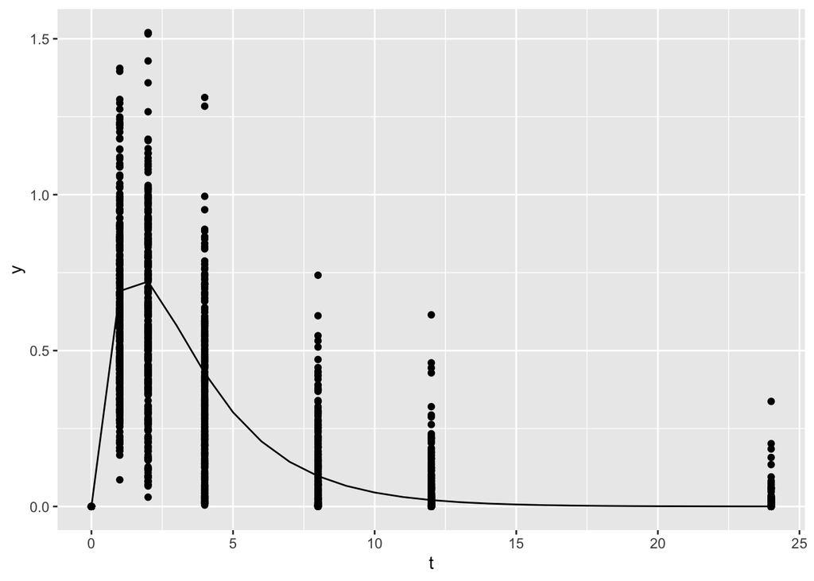

```r
# challenge: can you add the 300 mg dose data from simtab.csv to this plot?

data <- read.csv("simtab.csv") %>%
  filter(DOSE==300)

ggplot()+
  geom_line(data=my_simulated_df, aes(x=t,y=y))+
  geom_point(data=data, aes(x=TIME,y=DV))
```

# EXERCISE 2: Simulate alternate scenarios

Now that we have a model, we can use it to simulate alternate scenarios.

Make a new regimen with new_regimen() and change the amt and time to change the dose and frequency.

### Efficacy and Toxicity Thresholds

Can you find a regimen that keeps you in a therapeutic window that stays below the level of toxicity and above the level of efficacy?

```r
tox_threshold <- 2.8 #mg/L
eff_threshold <- 0.6 #mg/L
```

### New Regimens

```r
# Create a new regimen
# Look up ?new_regimen to see what arguments this function takes

#Instead of a single dose, now let's look at multiple doses across 4 weeks (28 days)
# HINT: for multiple dosing, you will need a vector of times.
# A vector can be created using c().
## ex. c(0,24,48,72)

# Another way is to use seq().
## ex. seq(start_time, end_time, increment)
## ex. daily dosing for 28 days: seq(0,28*24,24)

my_regimen <- new_regimen(amt=900, time=seq(0,28*24,6))
```

### Simulate new regimen

```r
# fill in the three arguments with our three components from above
my_simulated_df <- sim(ode = my_model,
                       regimen = my_regimen,
                       parameters = my_parameters,
                       only_obs = T,
                       output_include = list(variables=T),
                       t_obs = seq(0,31*24,0.1)
                       )
```

### Plot your simulation

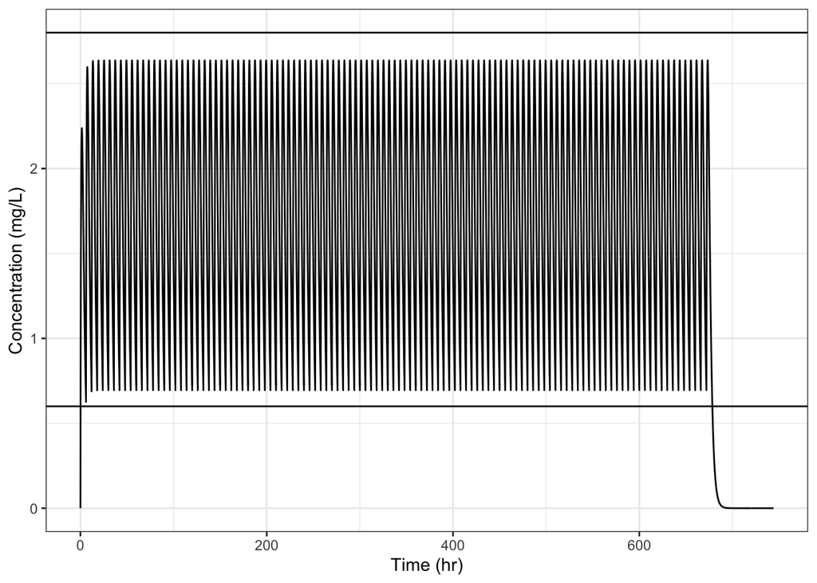

```r
# use ggplot to plot the data
# use geom_hline to add lines for your efficacy and toxicity thresholds

ggplot(my_simulated_df, mapping=aes(x=t,y=y))+
  geom_line()+
  geom_hline(yintercept = tox_threshold)+
  geom_hline(yintercept = eff_threshold)+
  ylab("Concentration (mg/L)")+
  xlab("Time (hr)")+
  theme_bw()
```

```r
# Are you within the therapeutic window?
# If not, simulate different regimens!
```

### Additional exploration

```r
# How does the plot change with increased frequency?
# higher drug accumulation before next dose, higher steady state concentrations

# How does the plot change with increased dose?
# much higher max drug concentration, slightly higher min drug concentration, higher overall steady state

# What's your recommendation? What dose do we need to stay in the therapeutic window?
# 900mg dose, 4 times daily
```

# EXERCISE 3: Challenge!

You are told that HIV+ patients are not receiving therapeutic doses  
Let’s confirm that for ourselves..

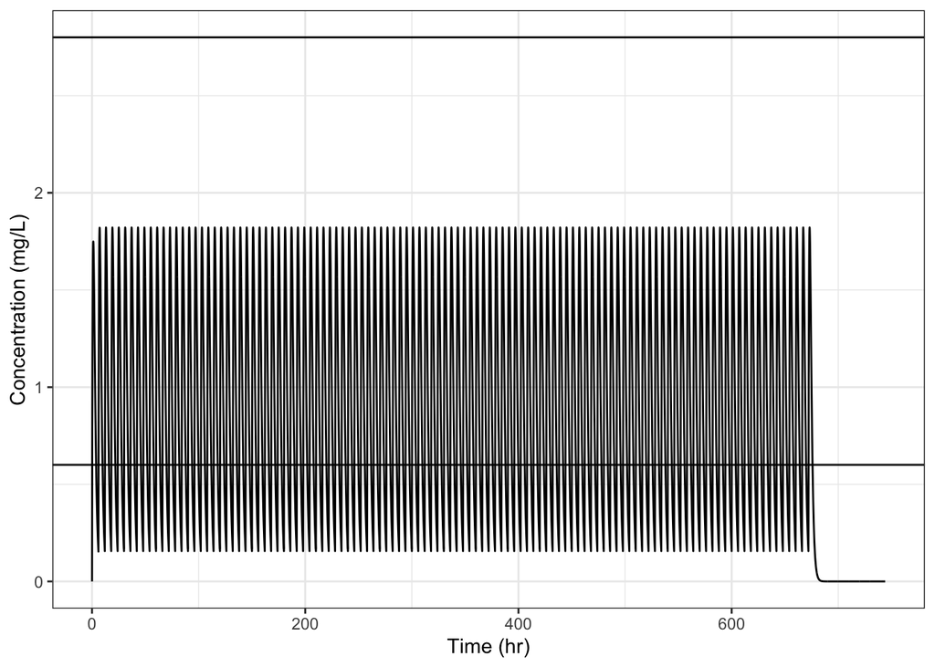

```r
# Input your PK parameters for the HIV subpopulation that you derived from the Rshiny app here:

V_HIV = 220
CL_HIV = 160
KA_HIV = 1

# We'll store these in a list that PKPDsim can read
HIV_parameters <- list("V"  = V_HIV,
                      "CL" = CL_HIV,
                      "KA" = KA_HIV
                      )

#Simulated dataset using your previously designed regimen
HIV_simulated_df <- sim(ode = my_model,
                       regimen = my_regimen,
                       parameters = HIV_parameters,
                       only_obs = T,
                       output_include = list(variables=T),
                       t_obs = seq(0,31*24,0.1)
                       )

#Plot the data
ggplot(HIV_simulated_df, mapping=aes(x=t,y=y))+
  geom_line()+
  geom_hline(yintercept = tox_threshold)+
  geom_hline(yintercept = eff_threshold)+
  ylab("Concentration (mg/L)")+
  xlab("Time (hr)")+
  theme_bw()
```

### Can you design a new dosing regimen specifically for this subpopulation?

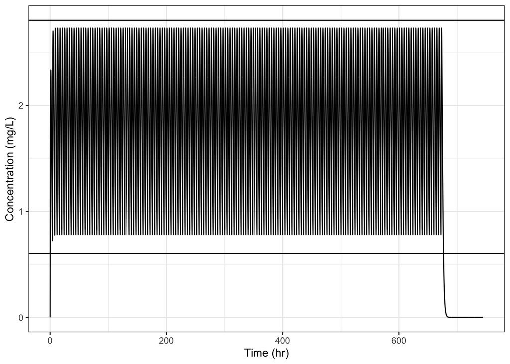

```r
#Let's design our new regimen, test different doses, times, and frequencies
HIV_regimen = new_regimen(amt=1200, time=seq(0,28*24,4))

#Simulated dataset using your newly designed regimen
HIV_simulated_df_new <- sim(ode = my_model,
                       regimen = HIV_regimen,
                       parameters = HIV_parameters,
                       only_obs = T,
                       output_include = list(variables=T),
                       t_obs = seq(0,31*24,0.1)
                       )

#Plot the data
ggplot(HIV_simulated_df_new, mapping=aes(x=t,y=y))+
  geom_line()+
  geom_hline(yintercept = tox_threshold)+
  geom_hline(yintercept = eff_threshold)+
  ylab("Concentration (mg/L)")+
  xlab("Time (hr)")+
  theme_bw()
```

```r
# Did you need to increase or decrease the dose? How about frequency? Why do you think that is?
# increase the dose, increase the frequency. This regimen was needed for HIV patients because of their higher CL, causing them to eliminate drug from their bodies faster.
```

# Shortcuts

To run an Rmd chunk all at once: CMD +SHIFT + RETURN  
To create a new Rmd chunk: OPTION + CMD + I  
To create a pipe (%>%) : CMD + SHIFT + M  
To create an arrow (<-) : OPTION + dash (-)  
To un/comment several lines at once: highlight lines + CMD + SHIFT + C